# Chi-Square - Test of Independence Example

# Problem Statement

Students at Virginia Tech studied which vehicles come to a complete stop at an intersection with four-way stop signs, selecting at random the cars to observe. They looked at several factors to see which (if any) were associated with coming to a complete stop. (They defined a complete stop as “the speed of the vehicle will become zero at least for an [instant]”). Some of these variables included the age of the driver, how many passengers were in the vehicle, and type of vehicle. The variable we are going to investigate is the arrival position of vehicles approaching an intersection all traveling in the same direction. They classified this arrival pattern into three groups: whether the vehicle arrives alone, is the lead in a group of vehicles, or is a follower in a group of vehicles. The students studied one specific intersection in Northern Virginia at a variety of different times. Because random assignment was not used, this is an observational study. Also note that no vehicle from one group is paired with a vehicle from another group. In other words, there is independence between the different groups of vehicles. (Tweaked a bit from Tintle et al. 2014 [p. 8-2 - 8-13])

# Competing Hypotheses

## In words

- Null hypothesis: There is no association between the arrival position of the vehicle and whether or not it comes to a complete stop.
- Alternative hypothesis: There is an association between the arrival position of the vehicle and whether or not it comes to a complete stop.

## Another way in words

- Null hypothesis: The long-run probability that a single vehicle will stop is the **same** as the long-run probability a lead vehicle will stop, which is the **same** as the long-run probability that a following vehicle will stop. In other words all three long-run probabilities are actually the same.
- Alternative hypothesis: At least one of these parameter (long-run) probabilities is different from the others

## In symbols (with annotations)

- $H_0: p_{single} = p_{lead} = p_{follow}$, where $p$ represents the long-run probability a vehicle will stop.
- $H_A$: At least one of these parameter probabilities is different from the others

## Set $\alpha$

It’s important to set the significance level before starting the testing using the data. Let’s set the significance level at 5% here.

# Exploring the sample data

```r
stop <- c(rep("complete", 265), rep("not_complete", 52))
vehicle_type <- c(rep("single", 151), rep("lead", 38), rep("follow", 76),
  rep("single", 25), rep("lead", 5), rep("follow", 22))
vehicles <- tibble(stop, vehicle_type)
```

```r
vehicles |>
  tabyl(vehicle_type, stop)
```

```
##  vehicle_type complete not_complete
##        follow       76           22
##          lead       38            5
##        single      151           25
```

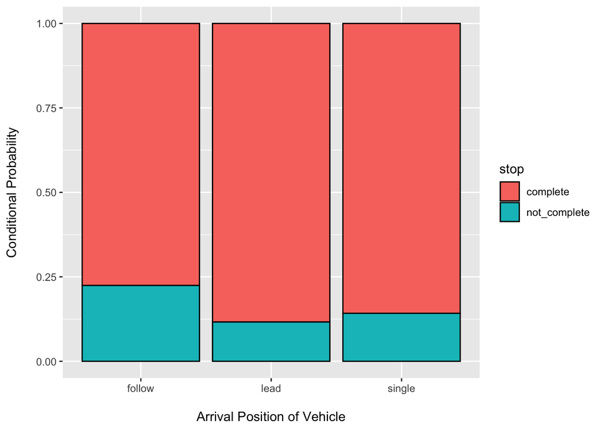

```r
ggplot(data = vehicles, mapping = aes(x = vehicle_type, fill = stop)) +
  geom_bar(position = "fill", color = "black") +
  xlab("\nArrival Position of Vehicle") +
  ylab("Conditional Probability\n")
```

## Guess about statistical significance

We are looking to see if a difference exists in the heights of the bars corresponding to `complete`. Based solely on the picture, we have reason to believe that a difference exists since the `follow` bar seems to be lower than the other two by quite a big margin. BUT…it’s important to use statistics to see if that difference is actually statistically significant!

# Non-traditional methods

We’ll use the **`infer`** package to carry out the simulation-based workflow with the $\chi^2$ statistic.

## Observed statistic

```r
chisq_hat <- vehicles |>
  specify(stop ~ vehicle_type) |>
  hypothesize(null = "independence") |>
  calculate(stat = "Chisq")
chisq_hat
```

```
## Response: stop (factor)
## Explanatory: vehicle_type (factor)
## Null Hypothesis: i...
## # A tibble: 1 × 1
##    stat
##   <dbl>
## 1  3.95
```

## Randomization for Hypothesis Test

Under the null of no association, the `stop` and `vehicle_type` labels are exchangeable, so `infer` shuffles them with `hypothesize(null = "independence")` and recomputes the $\chi^2$ statistic 10,000 times to build the null distribution.

```r
set.seed(2018)
null_distn <- vehicles |>
  specify(stop ~ vehicle_type) |>
  hypothesize(null = "independence") |>
  generate(reps = 10000, type = "permute") |>
  calculate(stat = "Chisq")
```

The $\chi^2$ statistic is always non-negative, so larger values are more extreme — this is a one-sided (right-tailed) test.

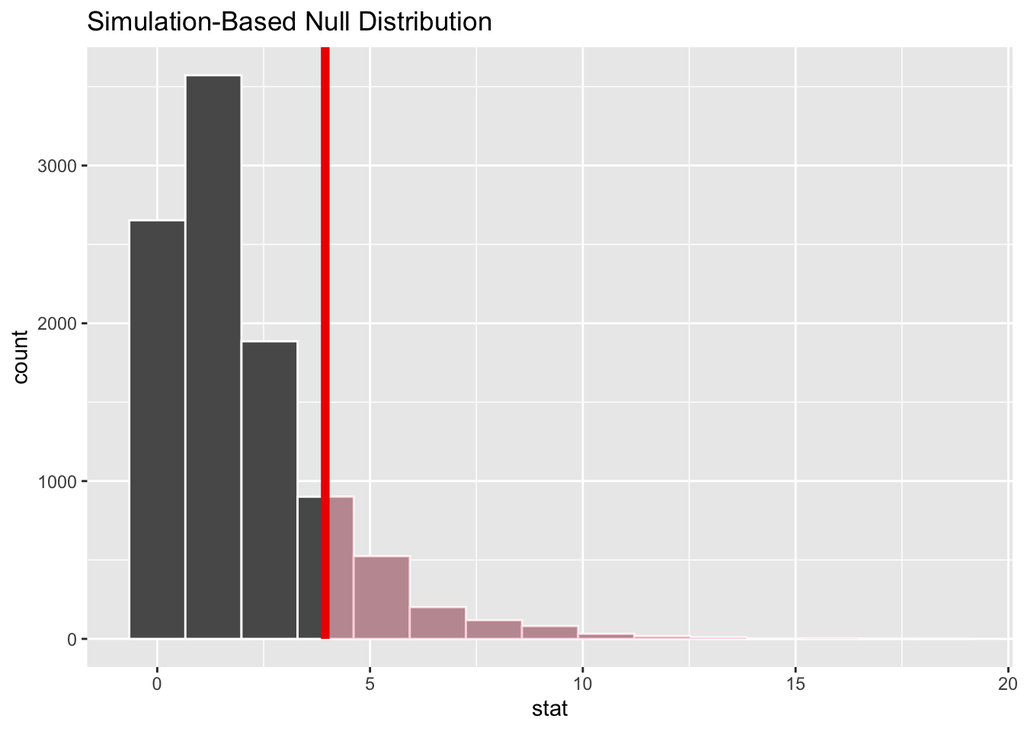

```r
null_distn |>
  visualize() +
  shade_p_value(obs_stat = chisq_hat, direction = "greater")
```

We can also overlay the theoretical $\chi^2$ distribution to compare the simulation-based and theory-based null distributions:

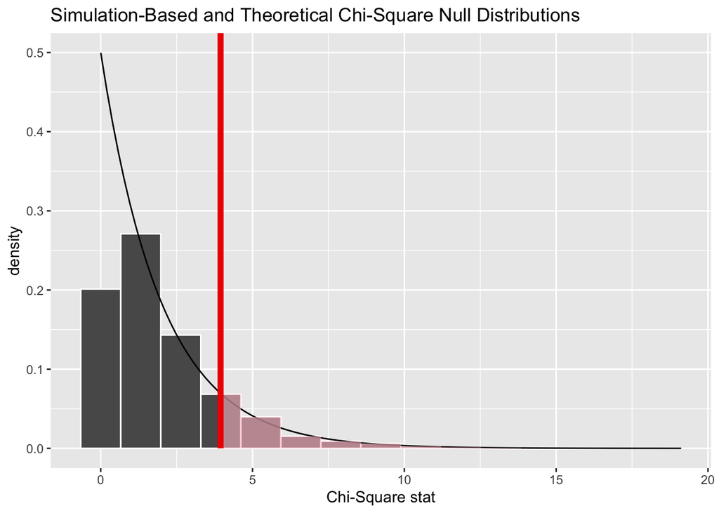

```r
null_distn |>
  visualize(method = "both") +
  shade_p_value(obs_stat = chisq_hat, direction = "greater")
```

### Calculate $p$-value

```r
pvalue <- null_distn |>
  get_p_value(obs_stat = chisq_hat, direction = "greater")
pvalue
```

```
## # A tibble: 1 × 1
##   p_value
##     <dbl>
## 1   0.134
```

So our $p$-value is 0.134 and we fail to reject the null hypothesis at the 5% level.

# Traditional methods

## Check conditions

Remember that in order to use the short-cut (formula-based, theoretical) approach, we need to check that some conditions are met.

1. *Independence*: Each case that contributes a count to the table must be independent of all the other cases in the table.

   This condition is met since cars were selected at random to observe.
2. *Sample size*: Each cell count must have at least 5 expected cases.

   This is met by observing the table above.

## Test statistic

The test statistic measures deviations from what we would expect in the cells of the table if the null hypothesis were true. This requires us to calculate expected counts via

$$\text{Expected Count}_{\text{row } i,
\text{col } j} = \dfrac{\text{row } i \text{ total} \times \text{column
} j \text{ total}}{\text{table total}}$$

$$X^2 = \sum_{\text{all cells in the
table}} \dfrac{(\text{observed count} - \text{expected
count})^2}{\text{expected count}}$$

Assuming the conditions outlined above are met, $X^2 \sim \chi^2(df = (R - 1) \times (C - 1))$ where $R$ is the number of rows in the table and $C$ is the number of columns.

## Observed test statistic

We can use `infer`’s `chisq_test()` wrapper to perform the theory-based test for us, which reports the $\chi^2$ statistic, degrees of freedom, and $p$-value.

```r
vehicles |>
  chisq_test(stop ~ vehicle_type)
```

```
## # A tibble: 1 × 3
##   statistic chisq_df p_value
##       <dbl>    <int>   <dbl>
## 1      3.95        2   0.139
```

## Compute $p$-value

We see that the theory-based $p$-value closely matches the simulation-based $p$-value from above, both leading to the same conclusion.

# State conclusion

We, therefore, do not have sufficient evidence to reject the null hypothesis. Our initial guess that a statistically significant difference existed in the proportions was not backed up by this statistical analysis. We do not have evidence to suggest that there is a dependency between the arrival position of the vehicle and whether or not it comes to a complete stop.

# Comparing results

The simulation-based and theory-based approaches give very similar $p$-values here, as the overlaid distributions above suggest. Since the conditions for the theory-based test are met, both the randomization and $\chi^2$-distribution approaches lead to the same conclusion.

Tintle, Nathan, Beth Chance, George Cobb, et al. 2014. *Introduction to Statistical Investigations*.